# Cyclistic Case Study

Luca Nasillo

2025-10-24

This project was completed as part of the Google Data Analytics Capstone project to explore user behaviour and membership conversion strategies for Cyclistic Bike Share.

## Executive Summary

This case study analyzes **Cyclistic’s bike-share** usage data to understand differences between **casual riders** and **annual members** to then identify opportunities to convert casual users into long-term members. Using 2019 and 2020 Q1 trip data, this analysis employed **R, tidyverse, lubridate, and geospatial** tools to clean, process, and visualise user behaviour.

Findings reveal that **casual riders take longer, leisure-oriented trips**, often near tourist hotspots, whereas **members ride more frequently during weekday commuting hours**. Casual riders’ top stations were twice as close to Chicago’s main attractions, reinforcing their recreational nature.

Based on these insights, Cyclistic should implement **seasonal or short-term membership bundles**, introduce a **‘leisure tier’ membership**, and **dynamically position bikes** by time of day and location to better match demand.

# ASK

## Business Task:

Understand how casual riders differ from members so Cyclistic can design bespoke strategies to convert casual riders into members.

## Primary Questions:

- 1. How do trip durations differ by rider type?
- 2. How do ride volumes vary by day and hour?
- 3. Which start stations are most used by each segment?

## Stakeholders: Marketing, Operations, Executive Team

# Prepare

## Data Sources:

Data sourced from public Divvy/Cyclistic trip data (no PII). For Posit’s memory limits, this project uses 2019 Q1 and 2020 Q1 CSVs. Tourism hotspots identified via https://www.touropia.com/tourist-attractions-in-chicago/ & coordinates determined via https://www.google.com/maps/@51.3752576,0.5321047,14z?entry=ttu&g_ep=EgoyMDI1MTAyNi4wIKXMDSoASAFQAw%3D%3D

### Tools: R, RStudio, tidyverse, lubridate, skimr, here. janitor, scales, leaflet, leaflet.extras, htmlwidgets, geosphere.

## Importation of Data:

```r
library(tidyverse)
library(lubridate)
library(skimr)
library(here)
library(janitor)
library(scales)
raw19 <- read_csv(here("raw_data","Divvy_Trips_2019_Q1 - Divvy_Trips_2019_Q1.csv"))
raw20 <- read_csv(here("raw_data","Divvy_Trips_2020_Q1 - Divvy_Trips_2020_Q1.csv"))
```

### Structure Check:

```r
skim(raw19)
```

Data summary

| Name | raw19 |
| --- | --- |
| Number of rows | 365069 |
| Number of columns | 12 |
| _______________________ |  |
| Column type frequency: |  |
| character | 6 |
| numeric | 6 |
| ________________________ |  |
| Group variables | None |

**Variable type: character**

| skim_variable | n_missing | complete_rate | min | max | empty | n_unique | whitespace |
| --- | --- | --- | --- | --- | --- | --- | --- |
| start_time | 0 | 1.00 | 18 | 19 | 0 | 343022 | 0 |
| end_time | 0 | 1.00 | 18 | 19 | 0 | 338367 | 0 |
| from_station_name | 0 | 1.00 | 10 | 43 | 0 | 594 | 0 |
| to_station_name | 0 | 1.00 | 10 | 43 | 0 | 600 | 0 |
| usertype | 0 | 1.00 | 8 | 10 | 0 | 2 | 0 |
| gender | 19711 | 0.95 | 4 | 6 | 0 | 2 | 0 |

**Variable type: numeric**

| skim_variable | n_missing | complete_rate | mean | sd | p0 | p25 | p50 | p75 | p100 | hist |
| --- | --- | --- | --- | --- | --- | --- | --- | --- | --- | --- |
| trip_id | 0 | 1.00 | 21960871.66 | 127175.00 | 21742443 | 21848765 | 21961829 | 22071823 | 22178528 | ▇▇▇▇▇ |
| bikeid | 0 | 1.00 | 3429.48 | 1923.32 | 1 | 1777 | 3489 | 5157 | 6471 | ▆▆▆▆▇ |
| tripduration | 0 | 1.00 | 1016.34 | 27913.51 | 61 | 326 | 524 | 866 | 10628400 | ▇▁▁▁▁ |
| from_station_id | 0 | 1.00 | 198.09 | 153.49 | 2 | 76 | 170 | 287 | 665 | ▇▅▃▁▁ |
| to_station_id | 0 | 1.00 | 198.58 | 154.47 | 2 | 76 | 168 | 287 | 665 | ▇▅▃▁▁ |
| birthyear | 18023 | 0.95 | 1981.67 | 11.25 | 1900 | 1975 | 1985 | 1990 | 2003 | ▁▁▁▅▇ |

```r
skim(raw20)
```

Data summary

| Name | raw20 |
| --- | --- |
| Number of rows | 426887 |
| Number of columns | 13 |
| _______________________ |  |
| Column type frequency: |  |
| character | 7 |
| numeric | 6 |
| ________________________ |  |
| Group variables | None |

**Variable type: character**

| skim_variable | n_missing | complete_rate | min | max | empty | n_unique | whitespace |
| --- | --- | --- | --- | --- | --- | --- | --- |
| ride_id | 0 | 1 | 8 | 16 | 0 | 426887 | 0 |
| rideable_type | 0 | 1 | 11 | 11 | 0 | 1 | 0 |
| started_at | 0 | 1 | 18 | 19 | 0 | 399265 | 0 |
| ended_at | 0 | 1 | 18 | 19 | 0 | 399532 | 0 |
| start_station_name | 0 | 1 | 5 | 43 | 0 | 607 | 0 |
| end_station_name | 1 | 1 | 5 | 43 | 0 | 602 | 0 |
| member_casual | 0 | 1 | 6 | 6 | 0 | 2 | 0 |

**Variable type: numeric**

| skim_variable | n_missing | complete_rate | mean | sd | p0 | p25 | p50 | p75 | p100 | hist |
| --- | --- | --- | --- | --- | --- | --- | --- | --- | --- | --- |
| start_station_id | 0 | 1 | 209.80 | 163.22 | 2.00 | 77.00 | 176.00 | 298.00 | 675.00 | ▇▆▃▁▁ |
| end_station_id | 1 | 1 | 209.34 | 163.20 | 2.00 | 77.00 | 175.00 | 297.00 | 675.00 | ▇▅▃▁▁ |
| start_lat | 0 | 1 | 41.90 | 0.04 | 41.74 | 41.88 | 41.89 | 41.92 | 42.06 | ▁▁▇▂▁ |
| start_lng | 0 | 1 | -87.64 | 0.02 | -87.77 | -87.66 | -87.64 | -87.63 | -87.55 | ▁▁▇▇▁ |
| end_lat | 1 | 1 | 41.90 | 0.04 | 41.74 | 41.88 | 41.89 | 41.92 | 42.06 | ▁▁▇▂▁ |
| end_lng | 1 | 1 | -87.64 | 0.02 | -87.77 | -87.66 | -87.64 | -87.63 | -87.55 | ▁▁▇▇▁ |

# Process:

## Cleaning Decisions and Standardisation:

- Renamed 2019 columns to align with those of 2020.
- Standardised rider labels: subscriber = member, customer = casual.
- Ensured ride_id is formatted in character in both datasets.
- Ensured both datasets included start station coordinates.
- Resolved timestamps and then calculated duration of journeys (minutes).
- Gave weekdays Mon-Sun labels.
- Removed implausible trips (≤1 min or ≥12 hr) and critical N/A rows.
- Combined 2019 & 2020 Tables as 1.

## Standardise - Adjusting Column Names:

```r
p19 <- raw19 %>%
  rename(
    ride_id=trip_id, started_at=start_time, ended_at=end_time,
    start_station_name=from_station_name, start_station_id=from_station_id,
    end_station_name=to_station_name, end_station_id=to_station_id,
    member_casual=usertype
  ) %>%
  mutate(member_casual = recode(tolower(member_casual),
                                "subscriber"="member", "customer"="casual"))
```

## 2020 Already Has Member/Casual but we Normalise Just in Case:

```r
p20 <- raw20 %>%
  mutate(member_casual = recode(tolower(member_casual),
                                "subscriber"="member", "customer"="casual"))
```

## Formatting ride_id Correctly:

```r
p19 <- p19 %>%
  mutate(ride_id = as.character(ride_id))
p20 <- p20 %>%
  mutate(ride_id = as.character(ride_id))
```

## Combining Tables with Common Fields:

```r
p19 <- p19 %>%
  mutate(start_lng = NA_real_, start_lat = NA_real_)

trips <-bind_rows(
  p19 %>% select(ride_id, started_at, ended_at, start_station_id, end_station_id,
                 start_station_name, end_station_name, member_casual, start_lat, start_lng),
  p20 %>% select(ride_id, started_at, ended_at, start_station_id, end_station_id,
                 start_station_name, end_station_name, member_casual, start_lat, start_lng)
)
```

## Filling in Missing Station Corrdinates from 2019 Dataset:

```r
# Joining Station Coordinates from p20 Dataset onto the Combined Dataset
## Determine Each Station's Coordinates:
station_lookup_id <- p20 %>%
  filter(!is.na(start_station_id), !is.na(start_lat), !is.na(start_lng)) %>%
  group_by(start_station_id) %>%
  summarise(
    start_lat_lookup = mean(as.numeric(start_lat), na.rm = TRUE),
    start_lng_lookup = mean(as.numeric(start_lng), na.rm = TRUE),
    .groups = "drop"
  )
## Join Coordinates onto Combined Dataset:
trips <- trips %>%
  left_join(station_lookup_id, by = "start_station_id") %>%
  mutate(
    start_lat = dplyr::coalesce(as.numeric(start_lat), start_lat_lookup),
    start_lng = dplyr::coalesce(as.numeric(start_lng), start_lng_lookup)
  ) %>%
  select(-start_lat_lookup, -start_lng_lookup)
```

## Feature Engineering (Timestamps, Monday-start Lables & Dropping NAs)

```r
trips_clean <- trips %>%
  mutate(
    started_at = ymd_hms(started_at, quiet = TRUE),
    ended_at = ymd_hms(ended_at, quiet = TRUE),
    ride_length_sec = as.numeric(difftime(ended_at, started_at, units = "secs")),
    ride_length_mins = ride_length_sec/60,
    day_of_week = wday(started_at, week_start = 1, label = TRUE),
    month = month(started_at, label = TRUE),
    hour = hour(started_at)
  ) %>%
  filter(!is.na(started_at), !is.na(ended_at),
        ride_length_mins > 1, ride_length_mins < 720) %>% # Removes Implausible Trips
  drop_na(member_casual)
```

Trips shorter than 1 minute or longer than 12 hours were excluded as likely data errors. ### Post-Clean Check:

```r
skim(trips_clean)
```

Data summary

| Name | trips_clean |
| --- | --- |
| Number of rows | 783363 |
| Number of columns | 15 |
| _______________________ |  |
| Column type frequency: |  |
| character | 4 |
| factor | 2 |
| numeric | 7 |
| POSIXct | 2 |
| ________________________ |  |
| Group variables | None |

**Variable type: character**

| skim_variable | n_missing | complete_rate | min | max | empty | n_unique | whitespace |
| --- | --- | --- | --- | --- | --- | --- | --- |
| ride_id | 0 | 1 | 7 | 16 | 0 | 783363 | 0 |
| start_station_name | 0 | 1 | 5 | 43 | 0 | 636 | 0 |
| end_station_name | 0 | 1 | 5 | 43 | 0 | 636 | 0 |
| member_casual | 0 | 1 | 6 | 6 | 0 | 2 | 0 |

**Variable type: factor**

| skim_variable | n_missing | complete_rate | ordered | n_unique | top_counts |
| --- | --- | --- | --- | --- | --- |
| day_of_week | 0 | 1 | TRUE | 7 | Tue: 134552, Thu: 131595, Wed: 128869, Fri: 122471 |
| month | 0 | 1 | TRUE | 3 | Mar: 304120, Jan: 245623, Feb: 233620, Apr: 0 |

**Variable type: numeric**

| skim_variable | n_missing | complete_rate | mean | sd | p0 | p25 | p50 | p75 | p100 | hist |
| --- | --- | --- | --- | --- | --- | --- | --- | --- | --- | --- |
| start_station_id | 0 | 1 | 202.03 | 155.84 | 2.00 | 77.00 | 174.00 | 289.00 | 675.00 | ▇▅▃▁▁ |
| end_station_id | 0 | 1 | 202.00 | 156.23 | 2.00 | 77.00 | 173.00 | 289.00 | 675.00 | ▇▅▃▁▁ |
| start_lat | 40 | 1 | 41.90 | 0.04 | 41.74 | 41.88 | 41.89 | 41.91 | 42.06 | ▁▁▇▂▁ |
| start_lng | 40 | 1 | -87.64 | 0.02 | -87.77 | -87.65 | -87.64 | -87.63 | -87.55 | ▁▁▇▇▁ |
| ride_length_sec | 0 | 1 | 794.32 | 1165.86 | 61.00 | 333.00 | 541.00 | 913.00 | 43002.00 | ▇▁▁▁▁ |
| ride_length_mins | 0 | 1 | 13.24 | 19.43 | 1.02 | 5.55 | 9.02 | 15.22 | 716.70 | ▇▁▁▁▁ |
| hour | 0 | 1 | 13.29 | 4.65 | 0.00 | 9.00 | 14.00 | 17.00 | 23.00 | ▁▅▃▇▂ |

**Variable type: POSIXct**

| skim_variable | n_missing | complete_rate | min | max | median | n_unique |
| --- | --- | --- | --- | --- | --- | --- |
| started_at | 0 | 1 | 2019-01-01 00:04:37 | 2020-03-31 23:51:34 | 2020-01-06 19:26:01 | 734576 |
| ended_at | 0 | 1 | 2019-01-01 00:11:07 | 2020-04-01 01:00:13 | 2020-01-06 19:37:29 | 730156 |

# Analyse

This analysis explores differences between member and casual riders in trip duration and temporal/spatial riding patterns across Chicago. Each insight aims to reveal distinct usage motivations between the rider types (commuting/recreation) and hence guide potential membership conversion strategies.

## Trip Duration by Customer Type:

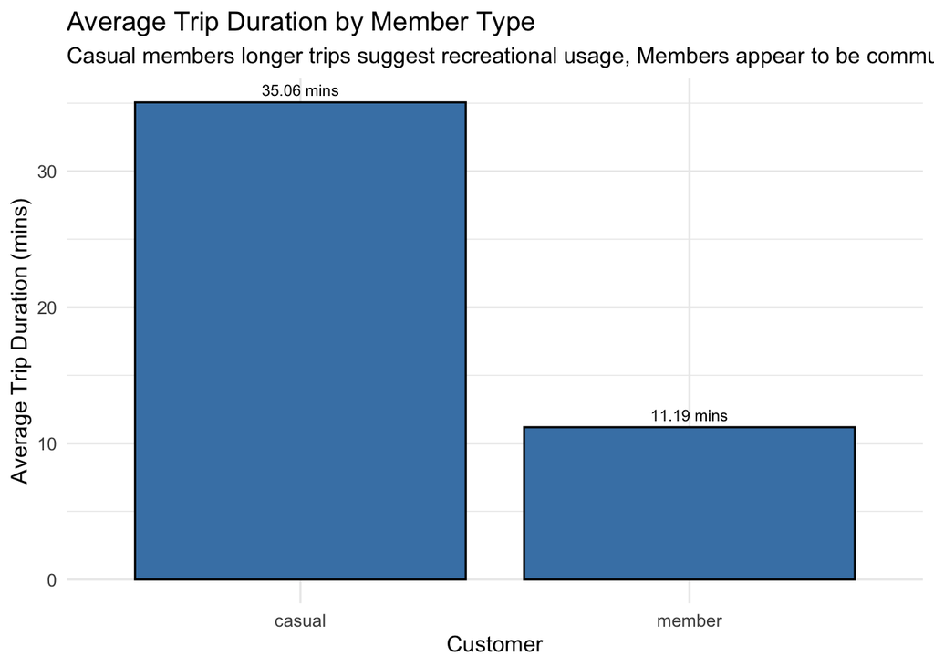

```r
# Mean & Max Trip Length by Customer Type
mean_max <- trips_clean %>%
  group_by(member_casual) %>%
  summarise(
    mean_duration = round(mean(ride_length_mins, na.rm= TRUE), 2),
    max_duration = max(ride_length_mins)
)
# Visualisation of Average Trip Duration by Customer Type
mean_max %>%
  ggplot(aes(x=member_casual, y=mean_duration)) +
  geom_col(width=0.85, colour = "black", fill = "steelblue") +
  geom_text(data=mean_max, aes(label=paste0(mean_duration, " mins")),
            vjust = -0.6, size=3, show.legend = FALSE) +
  labs(
    title = "Average Trip Duration by Member Type",
    subtitle = "Casual members longer trips suggest recreational usage, Members appear to be commuters",
    x = "Customer",
    y = "Average Trip Duration (mins)"
  ) +
  theme_minimal(base_size = 12)
```

- *Figure 1 - Average Trip Duration by Customer Type*

Casual riders take significantly longer trips on average. This suggests differing use cases:

- **Casual Riders** are likely using the service for **recreational or leisure**, where there are few time-constraints.
- **Members’** shorter trips suggest use-cases revolve around **purpose-driven commutes**.

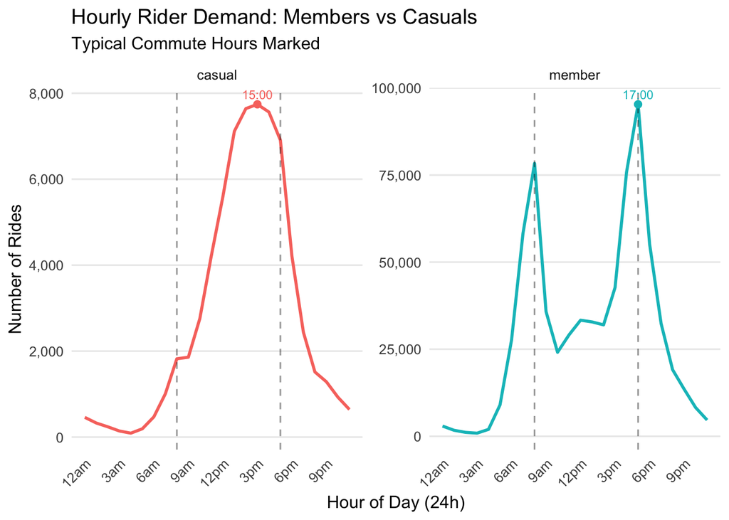

```r
# Determining Hourly Usage by Member Type:
hourly_usage <- trips_clean %>%
  count(member_casual, hour, name = "hour_vol")
# Identifying Peak Usage Hours by Member Type:
peak <- hourly_usage %>%
  group_by(member_casual) %>%
  slice_max(hour_vol,n=1)

hour_breaks <- c(0,3,6,9,12,15,18,21)
hour_labels <- c("12am","3am","6am","9am","12pm","3pm","6pm","9pm")
hour_boundaries <- c(0,23,1)

# Visualisation Showing Usage Hours by Member Type
hourly_usage %>%
  ggplot(aes(x=hour,y=hour_vol, colour = member_casual)) +
  geom_line(linewidth = 1) +
  facet_wrap(~member_casual, nrow=1, scales = "free_y") +
  geom_vline(xintercept = c(8,17), linetype = "dashed", alpha = 0.4) +
  geom_point(data = peak, size = 2) +
  geom_text(data=peak, aes(label=paste0(hour, ":00")),
            vjust = -0.6, size=3, show.legend = FALSE) +
  scale_x_continuous(breaks = hour_breaks, labels = hour_labels, limits = c(0,23)) +
  scale_y_continuous(labels=scales::comma) +
  labs(
    title = "Hourly Rider Demand: Members vs Casuals",
    subtitle = "Typical Commute Hours Marked",
    x = "Hour of Day (24h)",
    y = "Number of Rides",
    color = "Rider Type"
  ) +
  theme_minimal(base_size = 12) +
  theme(
    panel.grid.minor = element_blank(),
    panel.grid.major.x = element_blank(),
      legend.position = "none",
    axis.text.x = element_text(angle = 45, hjust = 1)
  )
```

- *Figure 2 - Usage Hours by Customer Type*

## Hourly Patterns by Customer Type

Analysing usage by hour reveals clear behavioural differences:

- **Casual** customers peak at **3pm**, indicating more flexible, recreational usage.

Higher weekend usage volume would support this.

- **Members** show two peaks at **8am** and **5pm** which align with typical commuting hours.

## Weekly Patterns by Customer Type

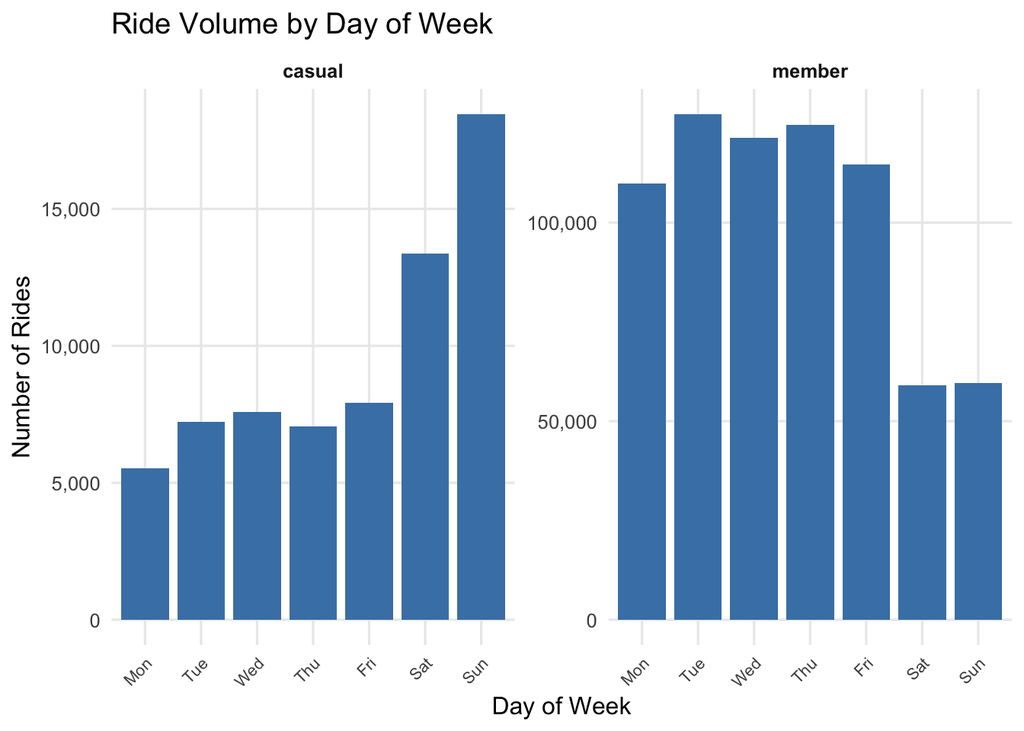

```r
day_counts <- trips_clean %>%
  count(member_casual, day_of_week, name = "day_volume")

day_counts %>%
ggplot(aes(x = day_of_week, y = day_volume)) +
  geom_col(width = 0.85, fill = "steelblue") +
  facet_wrap(~ member_casual, nrow = 1, scales = "free_y") +
  scale_y_continuous(labels = comma) +
  labs(
    title = "Ride Volume by Day of Week",
    x = "Day of Week",
    y = "Number of Rides",
  ) +
  theme_minimal(base_size = 12) +
  theme(
    panel.grid.minor = element_blank(),
    axis.text.x = element_text(angle = 45, hjust = 1, size = 8),
    strip.text = element_text(face = "bold")
  )
```

- *Figure 3 - Daily Usage by Customer Type*

Examining Usage Volumes Across the Week Strengthens this Contrast:

## Spatial Behaviour: Station Hotspots and Tourism Proximity

```r
#Importing Necessary Packages:
library(leaflet.extras)
library(geosphere)
library(htmlwidgets)
library(leaflet)

# Determine Station Usage by Customer Type:
start_station_volumes <- trips_clean %>%
  filter(!is.na(start_station_name), start_station_name != "") %>%
  count(member_casual, start_station_name, start_lat, start_lng, name = "station_volumes")

# Identifying Most Popular Stations by Customer Type:
top_stations <- start_station_volumes %>%
  group_by(member_casual) %>%
  slice_max(station_volumes, n= 15, with_ties = FALSE) %>%
  ungroup()

#Creating Colour Palette for the Visualisation
pal <- colorFactor(
  palette = c("goldenrod", "steelblue"),
  domain  = c("casual", "member")
)

#Determining Most Popular Station by Customer Type
peaks <-start_station_volumes %>%
  filter(!is.na(start_lat), !is.na(start_lng)) %>%
  group_by(member_casual) %>%
  slice_max(station_volumes, n=1)

# Adding Tourist Hotspots onto Map
hotspots_raw <- read_csv(here("raw_data","chicago_hotspots.csv")) %>%
  clean_names()

hotspots <- hotspots_raw %>%
  transmute(
    name = chicago_tourist_hot_spot,
    lat = as.numeric(lat),
    lng = as.numeric(long))

### Calculating Nearest Tourist Hotpot to each Top Station
nearest_hotspot <- top_stations %>%
  select(member_casual, start_station_name, start_lat, start_lng) %>%
  tidyr::crossing(
    hotspots %>% select(hotspot_name = name, lat, lng)
  ) %>%
  mutate(
    dist_m = geosphere::distHaversine(
      cbind(start_lng, start_lat),
      cbind(lng, lat)
    )
  ) %>%
  group_by(member_casual, start_station_name, start_lat, start_lng) %>%
  slice_min(dist_m, n = 1, with_ties = FALSE) %>%
  ungroup()
### Calculating % of Top Stations within Xm of A Tourist Hotspot & Summary Statistics
nearest_by_type <- nearest_hotspot %>%
  group_by(member_casual) %>%
  summarise(
    n_stations      = dplyr::n(),
    mean_dist_m     = mean(dist_m),
    median_dist_m   = median(dist_m),
    pct_within_125m = mean(dist_m <= 125)* 100,
    pct_within_250m = mean(dist_m <= 250) * 100,
    pct_within_500m = mean(dist_m <= 500) * 100,
    pct_within_1km  = mean(dist_m <= 1000) * 100,
    .groups = "drop"
  )
### Making Info Pop-up for Graph Displaying Key Summary Statistics
cas_med <- nearest_by_type %>%
  filter(member_casual=="casual") %>%
  pull(median_dist_m) %>%
  round(2)

mem_med <- nearest_by_type %>%
  filter(member_casual=="member") %>%
  pull(median_dist_m) %>%
  round(2)

cas_250 <- nearest_by_type %>%
  filter(member_casual=="casual") %>%
  pull(pct_within_250m) %>%
  round(2)

mem_250 <- nearest_by_type %>%
  filter(member_casual=="member") %>%
  pull(pct_within_250m) %>%
  round(2)

###Building HTML for the on-map Info Panel:
stats_html <- htmltools::HTML(
  sprintf(
    "<div style='background:white; padding:8px 10px; border-radius: 6px;
    box-shadow:0 1px 6px rgba(0,0,0,.18); font-size:13px;line-height:1.5'>
    <div style='font-weight:700; margin-bottom:4px; color:#333;'>Tourist Hotspot Proximity:</div>
    <div style='margin-bottom:6px;'>
    <span style='color:#555; width:70px;font-weight:600;'>Casual:</span><br/>
    <span style='color#000;'>Median Distance: <b>%s m</b></span><br/>
    <span style='color:#555; '>Within 250 m: <b>%s%%</b></span>
    </div>
    <div style='border-top:1px solid #eee; padding-topL:6px;'>
    <span style='color:#555; width:70px;font-weight:600;'>Members:</span><br/>
    <span style='color#000;'>Median Distance: <b>%s m</b></span><br/>
    <span style='color:#555; '>Within 250 m: <b>%s%%</b></span>
    </div>
    </div>",
    round(cas_med,1), round(cas_250,1), round(mem_med,1), round(mem_250,1)
  )
)

#Creating Interactive Map Visualisation of Spatial Usage by Customer Type with Tourist Hotspots Identified
map <- leaflet(top_stations) %>%
  addProviderTiles(providers$CartoDB.Positron) %>%
  addCircles(
    data = peaks,
    lng = ~start_lng, lat = ~start_lat,
    radius = 70,
    color = "black",
    weight = 2,
    fillOpacity = 0,
    options = pathOptions(interactive = FALSE),
    group = "Most Popular Station") %>%
  addCircleMarkers(
    lng = ~start_lng,
    lat = ~start_lat,
    radius = ~scales::rescale(station_volumes, to=c(5,20)),
    color = ~pal(member_casual),
    fillColor = ~pal(member_casual),
    fillOpacity = 0.7,
    stroke =TRUE, weight = 1,
    popup = ~paste0(
      "<b>", htmltools::htmlEscape(start_station_name), "</b><br/>",
      "Customer type: <b>", member_casual, "</b><br/>",
      "Rides: <b>", comma(station_volumes), "</b>"
    ),
    group = "Top Stations"
    ) %>%
  addHeatmap(
    data = hotspots,
    lng = ~lng, lat = ~lat,
    radius = 45,
    blur = 10,
    max = 2,
    group = "Tourist Hotspots"
  ) %>%
  addLayersControl(
    overlayGroups = c("Top Stations", "Most Popular Station", "Tourist Hotspots"),
    options = layersControlOptions(collapsed=FALSE)
  ) %>%
  addEasyButton(
    easyButton(
      icon = "fa-info", title = "Tourism Summary",
      onClick = JS(
        sprintf(
          "function(btn,map){
          var sz = map.getSize();
          var pt = L.point(120, sz.y - 10);
          var ll = map.containerPointToLatLng(pt)
          var html = `%s`;
          L.popup({
          autoPan: false,
          closeButton: true,
          offset: L.point(10,-10),
          maxWidth: 220,
          className: 'corner-popup'
          })
          .setLatLng(ll)
          .setContent(html)
          .openOn(map);
          }",
          gsub("`","\\\\`", as.character(stats_html))
        )
      )
    )
  ) %>%
  hideGroup("Tourist Hotspots") %>%
  addLegend(
    "bottomright",
    pal = pal, values = ~member_casual,
    title = "Customer Type"
  )

 map
```

[interactive chart not shown]

- *Figure 4 - Map Displaying Most Used Stations by Customer Type with Tourism Hotpsots Identified*

Mapping each customer type’s most popular stations highlights a strong spatial divide:

- **Casual** customers’ top stations cluster around central Chicago landmarks.
- **Member’** top stations are more dispersed, towards business districts and residential areas,

These Visual Patterns are Reinforced Statistically: **Median distances** from top Tourist Hotspots:

- Casual Customers: **~250m**
- Members: **~500m**

**Share of Stations within 250m** of a top Tourist Hotspot:

- Casual Customers: **47%**
- Members: **20%**

This indicates casual customers’ behaviour strongly aligns with **tourist and leisure zones**, while members’ activity reflects **daily commuting networks**.

## Summary and Next Steps:

Overall, the findings suggest a clear segmentation:

- Casual Customers = tourists and leisure users
- Members = commuters & frequent local users

This distinction can inform direction for marketing and operations teams:

- **For casuals:** promote **short-term membership bundles** at tourist-heavy locations or offer **discounts for weekend explorers**.
- **For members:** reinforce **commute reliability and convenience**, possibly introducing **loyalty incentives** for weekday use.

Further analysis could examine seasonal patterns or monthly demand shifts to better tailor campaigns across the year

# Act:

This section outlines strategic next steps and initial ideas for bespoke marketing initiatives designed to convert casual users into members, while improving system efficiency.

1. **Expand Network Access & Tiered Memberships:**
- introduce a **tiered membership system** with a dedicated **‘leisure tier’**, granting access to Cyclistic bikes across all the cities of operation.
- This would captures the tourist and travelling segment of our customer base, converting short-term uses into repeat, location-independent members.
2. **Offer Temporal Membership Options Aligned with Seasonal Demand**
- Introduce **3-month or 6-month membership options**, designed for seasonal riders.
- This strategy should be validated by analysing **monthly data trends** (not available in this analysis’ Q1-only dataset) to confirm peak periods - likely **spring & summer** when tourism and leisure activity increase.
3. **Dynamic Bike Distribution for Demand Optimisation**
- adjust **bike placement by time-of-day**:
  - **Morning:** concentrate supply in business and **residential districts** to support commuters.
  - **Late Morning to Afternoon:**: shift supply towards **central Chicago landmarks** to serve leisure users.
  - **Evening:**: redistribute to business and housing districts to accommodate return commutes.
- **Weekends:** maintain higher availability near tourist landmarks throughout the day to meet predominantly recreational demand.